# Templating with child documents

## Analysis of the “away” dataset

### Correlation plot

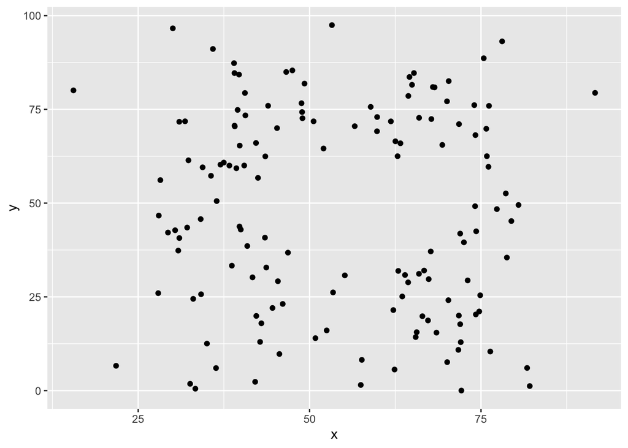

### Correlation test statistics

```
##
##  Pearson's product-moment correlation
##
## data:  d$x and d$y
## t = -0.76034, df = 140, p-value = 0.4483
## alternative hypothesis: true correlation is not equal to 0
## 95 percent confidence interval:
##  -0.2264633  0.1016730
## sample estimates:
##         cor
## -0.06412835
```

Note: These very impressive plots and statistics were calculated at 2024-02-08 13:44:23.800011

## Analysis of the “h_lines” dataset

### Correlation plot

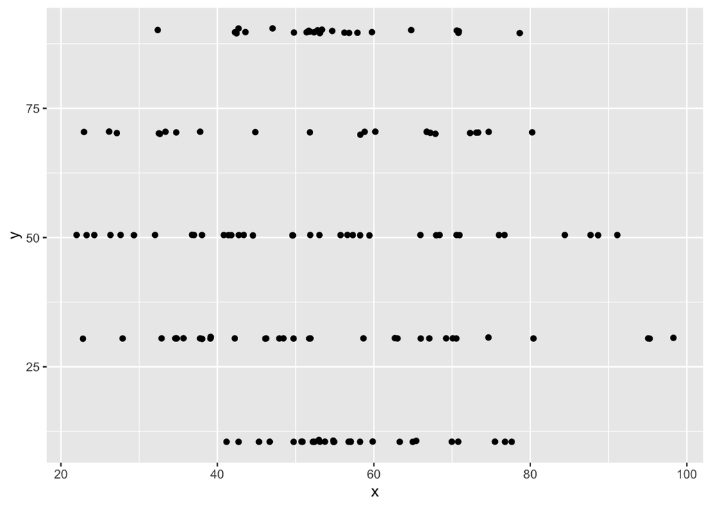

### Correlation test statistics

```
##
##  Pearson's product-moment correlation
##
## data:  d$x and d$y
## t = -0.73161, df = 140, p-value = 0.4656
## alternative hypothesis: true correlation is not equal to 0
## 95 percent confidence interval:
##  -0.2241632  0.1040704
## sample estimates:
##         cor
## -0.06171484
```

Note: These very impressive plots and statistics were calculated at 2024-02-08 13:44:23.881283

## Analysis of the “v_lines” dataset

### Correlation plot

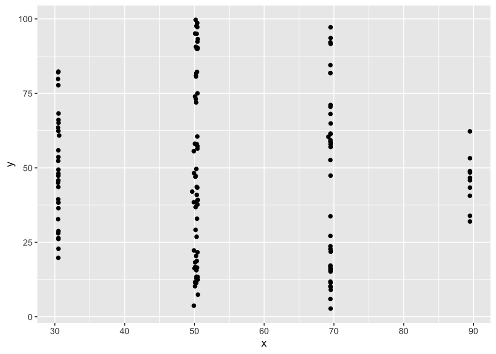

### Correlation test statistics

```
##
##  Pearson's product-moment correlation
##
## data:  d$x and d$y
## t = -0.82368, df = 140, p-value = 0.4115
## alternative hypothesis: true correlation is not equal to 0
## 95 percent confidence interval:
##  -0.2315243  0.0963843
## sample estimates:
##         cor
## -0.06944557
```

Note: These very impressive plots and statistics were calculated at 2024-02-08 13:44:23.962463

## Analysis of the “x_shape” dataset

### Correlation plot

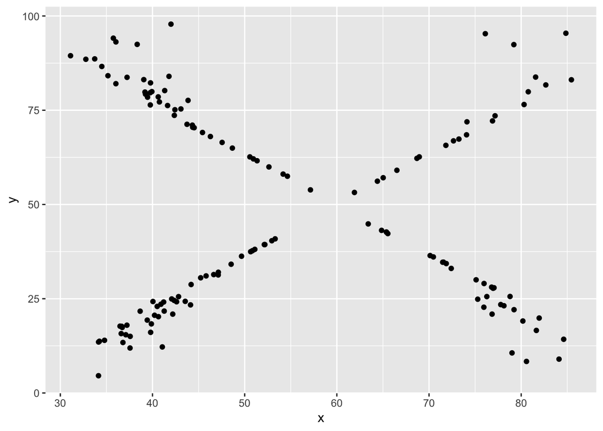

### Correlation test statistics

```
##
##  Pearson's product-moment correlation
##
## data:  d$x and d$y
## t = -0.77767, df = 140, p-value = 0.4381
## alternative hypothesis: true correlation is not equal to 0
## 95 percent confidence interval:
##  -0.2278491  0.1002267
## sample estimates:
##         cor
## -0.06558334
```

Note: These very impressive plots and statistics were calculated at 2024-02-08 13:44:24.03744

## Analysis of the “star” dataset

### Correlation plot

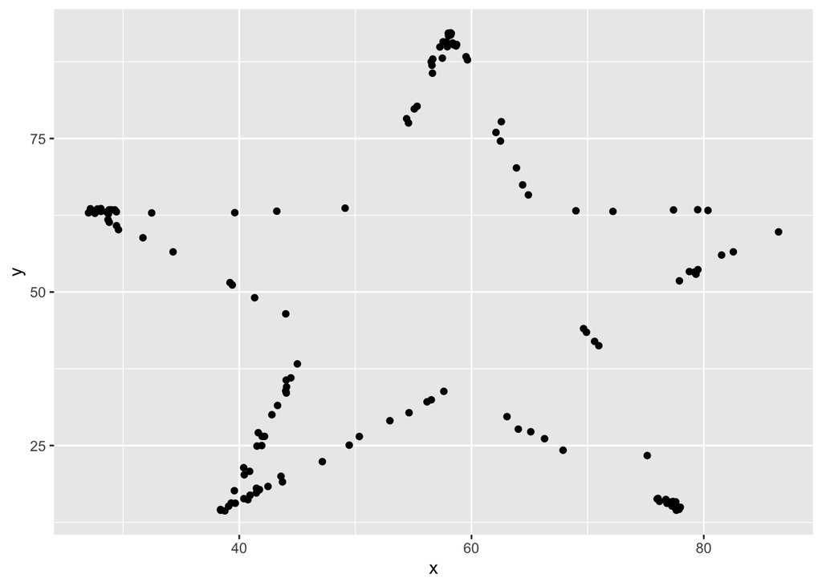

### Correlation test statistics

```
##
##  Pearson's product-moment correlation
##
## data:  d$x and d$y
## t = -0.74645, df = 140, p-value = 0.4566
## alternative hypothesis: true correlation is not equal to 0
## 95 percent confidence interval:
##  -0.2253512  0.1028327
## sample estimates:
##        cor
## -0.0629611
```

Note: These very impressive plots and statistics were calculated at 2024-02-08 13:44:24.111919

## Analysis of the “high_lines” dataset

### Correlation plot

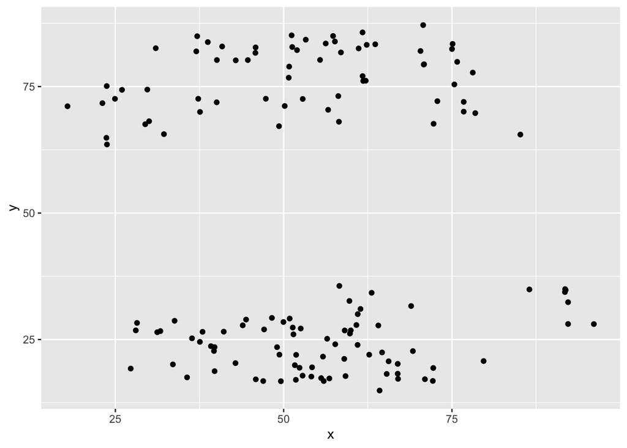

### Correlation test statistics

```
##
##  Pearson's product-moment correlation
##
## data:  d$x and d$y
## t = -0.81246, df = 140, p-value = 0.4179
## alternative hypothesis: true correlation is not equal to 0
## 95 percent confidence interval:
##  -0.23062896  0.09732128
## sample estimates:
##         cor
## -0.06850422
```

Note: These very impressive plots and statistics were calculated at 2024-02-08 13:44:24.187298

## Analysis of the “dots” dataset

### Correlation plot

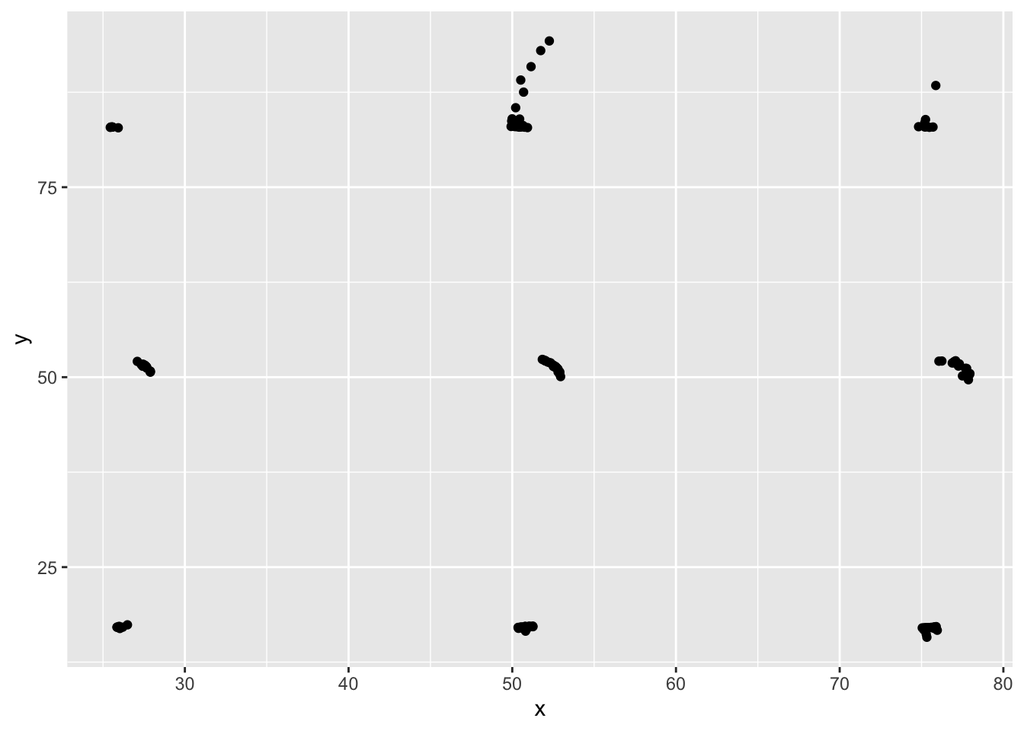

### Correlation test statistics

```
##
##  Pearson's product-moment correlation
##
## data:  d$x and d$y
## t = -0.71527, df = 140, p-value = 0.4756
## alternative hypothesis: true correlation is not equal to 0
## 95 percent confidence interval:
##  -0.2228536  0.1054338
## sample estimates:
##         cor
## -0.06034144
```

Note: These very impressive plots and statistics were calculated at 2024-02-08 13:44:24.265532

## Analysis of the “circle” dataset

### Correlation plot

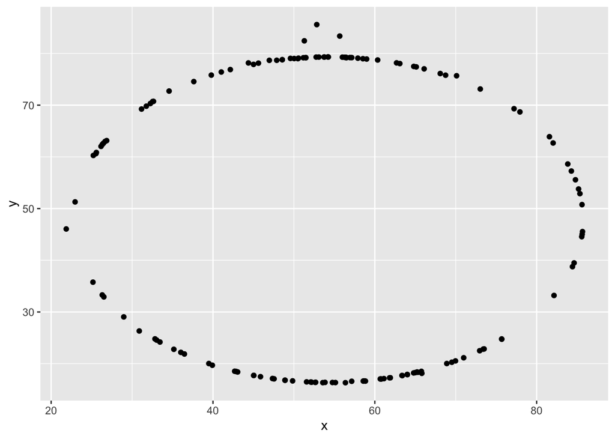

### Correlation test statistics

```
##
##  Pearson's product-moment correlation
##
## data:  d$x and d$y
## t = -0.81054, df = 140, p-value = 0.419
## alternative hypothesis: true correlation is not equal to 0
## 95 percent confidence interval:
##  -0.23047593  0.09748136
## sample estimates:
##         cor
## -0.06834336
```

Note: These very impressive plots and statistics were calculated at 2024-02-08 13:44:24.339824

## Analysis of the “bullseye” dataset

### Correlation plot

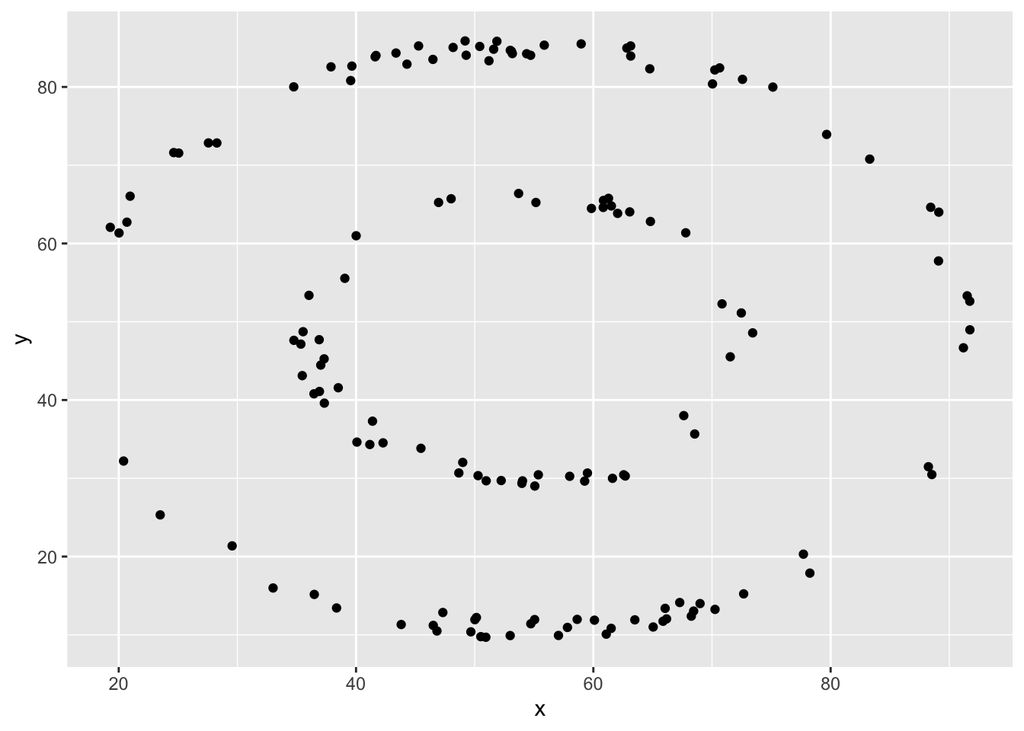

### Correlation test statistics

```
##
##  Pearson's product-moment correlation
##
## data:  d$x and d$y
## t = -0.81344, df = 140, p-value = 0.4173
## alternative hypothesis: true correlation is not equal to 0
## 95 percent confidence interval:
##  -0.2307071  0.0972395
## sample estimates:
##         cor
## -0.06858639
```

Note: These very impressive plots and statistics were calculated at 2024-02-08 13:44:24.414951

## Analysis of the “slant_up” dataset

### Correlation plot

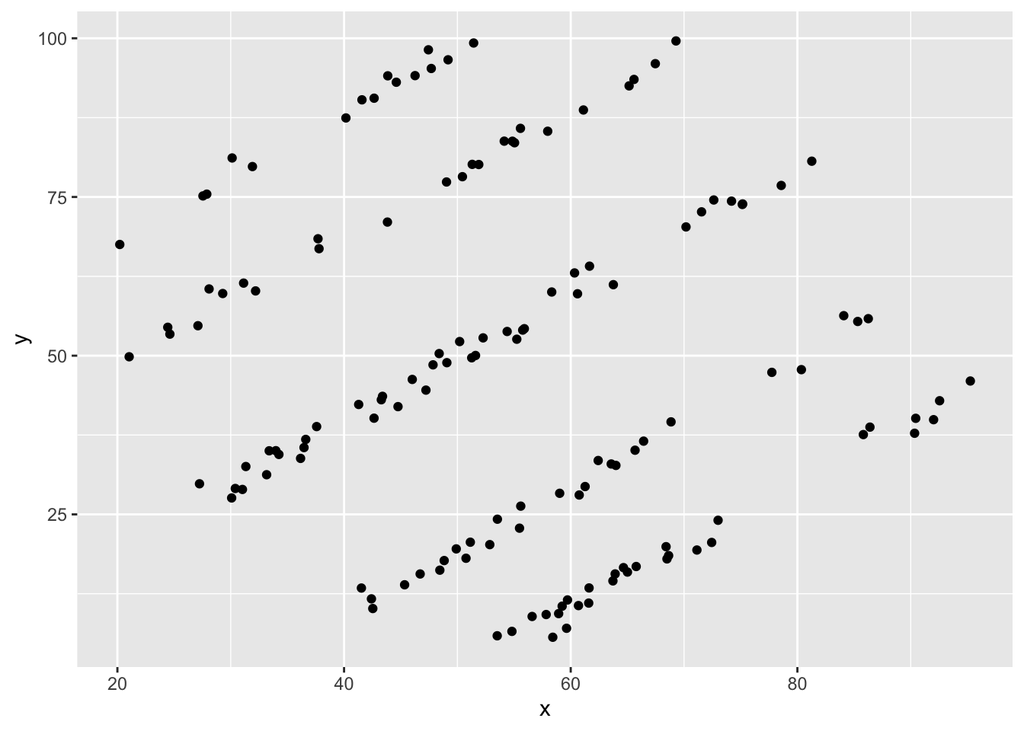

### Correlation test statistics

```
##
##  Pearson's product-moment correlation
##
## data:  d$x and d$y
## t = -0.81371, df = 140, p-value = 0.4172
## alternative hypothesis: true correlation is not equal to 0
## 95 percent confidence interval:
##  -0.23072883  0.09721679
## sample estimates:
##         cor
## -0.06860921
```

Note: These very impressive plots and statistics were calculated at 2024-02-08 13:44:24.490784

## Analysis of the “slant_down” dataset

### Correlation plot

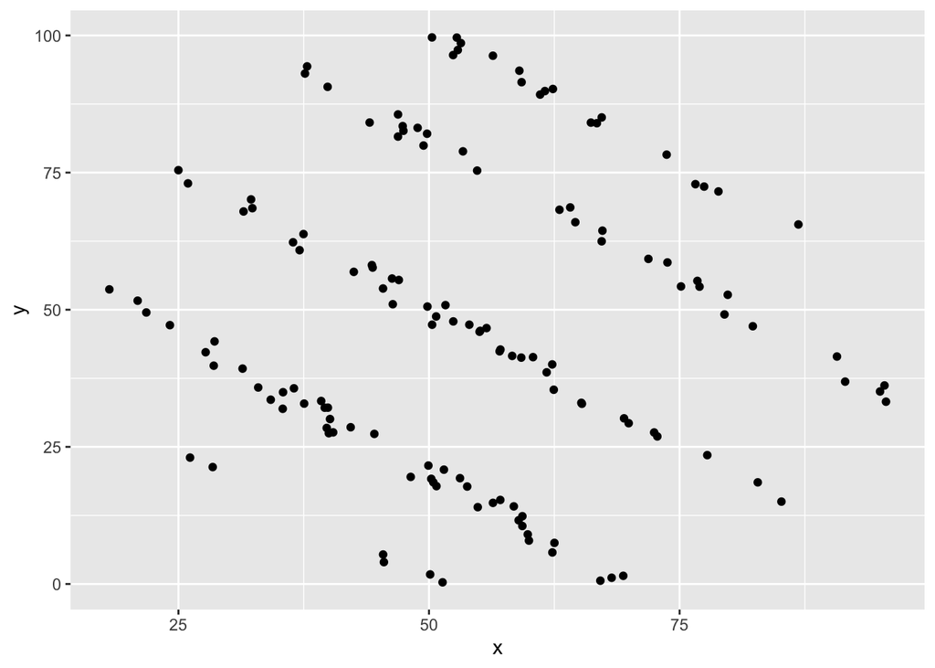

### Correlation test statistics

```
##
##  Pearson's product-moment correlation
##
## data:  d$x and d$y
## t = -0.81813, df = 140, p-value = 0.4147
## alternative hypothesis: true correlation is not equal to 0
## 95 percent confidence interval:
##  -0.23108127  0.09684801
## sample estimates:
##         cor
## -0.06897974
```

Note: These very impressive plots and statistics were calculated at 2024-02-08 13:44:24.572795

## Analysis of the “wide_lines” dataset

### Correlation plot

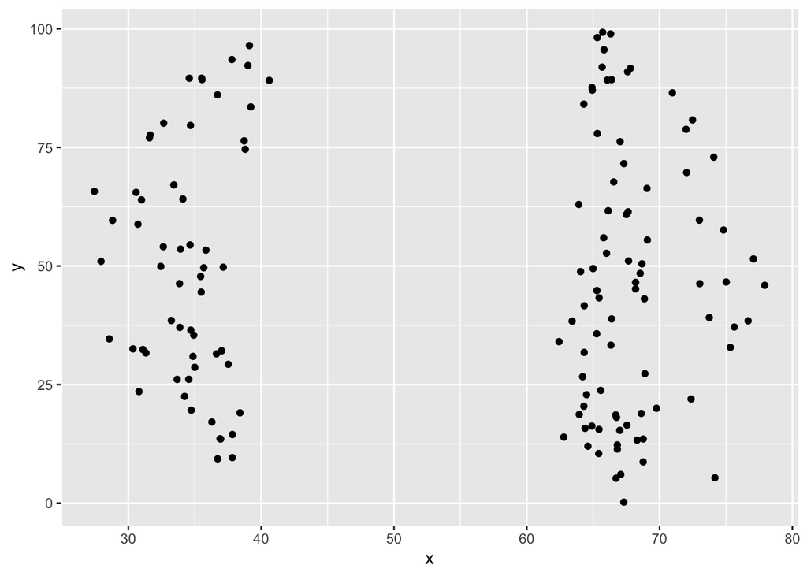

### Correlation test statistics

```
##
##  Pearson's product-moment correlation
##
## data:  d$x and d$y
## t = -0.78948, df = 140, p-value = 0.4312
## alternative hypothesis: true correlation is not equal to 0
## 95 percent confidence interval:
##  -0.22879338  0.09924039
## sample estimates:
##         cor
## -0.06657523
```

Note: These very impressive plots and statistics were calculated at 2024-02-08 13:44:24.649362